# Étude de cas Bellabeat

Joffrey Pelletier

2023-09-13

**Étude de cas BellaBeat**

Voici mon étude de cas Bellabeat dans le cadre de la certification Google Data Analytics. Je vais suivre les 6 étapes de l’analyse de données :

1)Demander

2)Préparer

3)Traiter

4)Analyser

5)Partager

6)Agir

**Contexte**

Cela fait maintenant six mois que j’ai intégré Bellabeat en tant qu’analyste de données junior. Bellabeat se distingue par ses trackers de santé, conçus spécifiquement pour répondre aux besoins des femmes. Ces dispositifs offrent des insights allant de la fertilité aux cycles menstruels, sans oublier la qualité du sommeil et l’activité physique.

Ma principale responsabilité en tant qu’analyste de données est de transformer les données brutes en informations pertinentes, permettant ainsi à l’équipe dirigeante de prendre des décisions éclairées et fondées sur des preuves concrètes.

# 1 Demander

Cette étape de l’analyse de données et cruciale pour orienter notre analyse dans la bonne direction. Pour cela je vais commencer par identifier les partenaire, définir les objectifs et les missions de la tache commerciale.

**Partenaires :**

- Urška Sršen : Cofondatrice et directrice de la création de Bellabeat
- Sando Mur : mathématicien et cofondateur de Bellabeat ; membre clé de l’équipe de direction de Bellabeat
- Équipe d’analyse marketing de Bellabeat : Une équipe d’analystes de données responsables de la collecte, de l’analyse et de la production de rapports sur les données qui aident à guider la stratégie marketing de Bellabeat

**Objectif :**

Urška Sršen m’a chargé d’analyser les données d’utilisation des appareils intelligents non Bellabeat afin de comprendre les habitudes des consommateurs. Sur la base de cette analyse, elle souhaite que j’adapte ces informations à un produit Bellabeat spécifique pour la présentation. J’ai choisi de me concentrer sur le produit Ivy qui est un bracelet connecté.

## 1.1 Missions de la tâche commerciale :

- Analyser l’utilisation des produits intelligents non Bellabeat pour identifier les tendances, préférences, et comportements dominants des consommateurs.
- Utiliser ces insights pour recommander des améliorations et des optimisations pour les produits Bellabeat.
- Fournir des informations clés à l’équipe de direction pour favoriser de nouvelles opportunités de croissance sur le marché mondial des appareils intelligents

# 2 Préparer

Les données utilisées pour cette analyse proviennent de la plateforme Kaggle. Elles ont été évaluées avec une note d’utilisabilité de 10 sur 10 sur Kaggle, attestant de leur qualité et de leur fiabilité. La licence sous laquelle ces données sont distribuées est la “CC0: Public Domain”, ce qui signifie qu’elles sont librement accessibles au public et peuvent être utilisées sans restrictions.Ces données ont été prétraitées avant leur mise à disposition, comme indiqué par la méthodologie de collecte “preprocessed”.

Pour ceux qui souhaitent consulter ou télécharger le jeu de données original, il est disponible à l’adresse suivante : [Dataset Fitbit sur Kaggle](https://www.kaggle.com/datasets/arashnic/fitbit)

**J’ai décidé de centrer mon analyse sur les colonnes liées au sommeil, à l’activité et au nombre de pas effectués au cours de la journée. Étant donné le grand nombre de colonnes et d’observations dans cet échantillon, j’espère y déceler des informations pertinentes.**

## 2.1 Installation et chargement des bibliothèques

Avant de commencer l’analyse, nous devons installer et charger les bibliothèques nécessaires pour notre analyse en R.

```r
# Liste des packages à installer
packages_to_install <- c("tidyverse", "lubridate", "dplyr", "ggplot2", "tidyr",
                         "readr", "plotly", "purrr", "stringr", "forcats",
                         "tibble", "rmarkdown","hms","skimr")

# Installer les packages
install.packages(packages_to_install, repos = "https://cran.r-project.org/")
# Charger les packages
lapply(packages_to_install, library, character.only=TRUE)
```

[output not shown]

[output cut: 17 more lines]

[output not shown]

## 2.2 Chargement des Données

Nous allons maintenant importer les quatre fichiers CSV séléctionnés pour notre analyse.

```r
# Chargement des données

sleep <- read_csv("sleepDay_merged.csv")
steps <- read_csv("hourlySteps_merged.csv")
minutesleep <- read_csv("minuteSleep_merged.csv")
activity <- read_csv("dailyActivity_merged.csv")
```

## 2.3 Vérification des données et de leurs formats

```r
# Vérification des premières lignes de chaque dataset
head(sleep)
```

```
## # A tibble: 6 × 5
##           Id SleepDay        TotalSleepRecords TotalMinutesAsleep TotalTimeInBed
##        <dbl> <chr>                       <dbl>              <dbl>          <dbl>
## 1 1503960366 4/12/2016 12:0…                 1                327            346
## 2 1503960366 4/13/2016 12:0…                 2                384            407
## 3 1503960366 4/15/2016 12:0…                 1                412            442
## 4 1503960366 4/16/2016 12:0…                 2                340            367
## 5 1503960366 4/17/2016 12:0…                 1                700            712
## 6 1503960366 4/19/2016 12:0…                 1                304            320
```

```r
head(steps)
```

```
## # A tibble: 6 × 3
##           Id ActivityHour          StepTotal
##        <dbl> <chr>                     <dbl>
## 1 1503960366 4/12/2016 12:00:00 AM       373
## 2 1503960366 4/12/2016 1:00:00 AM        160
## 3 1503960366 4/12/2016 2:00:00 AM        151
## 4 1503960366 4/12/2016 3:00:00 AM          0
## 5 1503960366 4/12/2016 4:00:00 AM          0
## 6 1503960366 4/12/2016 5:00:00 AM          0
```

```r
head(minutesleep)
```

```
## # A tibble: 6 × 4
##           Id date                 value       logId
##        <dbl> <chr>                <dbl>       <dbl>
## 1 1503960366 4/12/2016 2:47:30 AM     3 11380564589
## 2 1503960366 4/12/2016 2:48:30 AM     2 11380564589
## 3 1503960366 4/12/2016 2:49:30 AM     1 11380564589
## 4 1503960366 4/12/2016 2:50:30 AM     1 11380564589
## 5 1503960366 4/12/2016 2:51:30 AM     1 11380564589
## 6 1503960366 4/12/2016 2:52:30 AM     1 11380564589
```

```r
head(activity)
```

```
## # A tibble: 6 × 15
##           Id ActivityDate TotalSteps TotalDistance TrackerDistance
##        <dbl> <chr>             <dbl>         <dbl>           <dbl>
## 1 1503960366 4/12/2016         13162          8.5             8.5
## 2 1503960366 4/13/2016         10735          6.97            6.97
## 3 1503960366 4/14/2016         10460          6.74            6.74
## 4 1503960366 4/15/2016          9762          6.28            6.28
## 5 1503960366 4/16/2016         12669          8.16            8.16
## 6 1503960366 4/17/2016          9705          6.48            6.48
## # ℹ 10 more variables: LoggedActivitiesDistance <dbl>,
## #   VeryActiveDistance <dbl>, ModeratelyActiveDistance <dbl>,
## #   LightActiveDistance <dbl>, SedentaryActiveDistance <dbl>,
## #   VeryActiveMinutes <dbl>, FairlyActiveMinutes <dbl>,
## #   LightlyActiveMinutes <dbl>, SedentaryMinutes <dbl>, Calories <dbl>
```

```r
summary(sleep)
```

```
##        Id              SleepDay         TotalSleepRecords TotalMinutesAsleep
##  Min.   :1.504e+09   Length:413         Min.   :1.000     Min.   : 58.0
##  1st Qu.:3.977e+09   Class :character   1st Qu.:1.000     1st Qu.:361.0
##  Median :4.703e+09   Mode  :character   Median :1.000     Median :433.0
##  Mean   :5.001e+09                      Mean   :1.119     Mean   :419.5
##  3rd Qu.:6.962e+09                      3rd Qu.:1.000     3rd Qu.:490.0
##  Max.   :8.792e+09                      Max.   :3.000     Max.   :796.0
##  TotalTimeInBed
##  Min.   : 61.0
##  1st Qu.:403.0
##  Median :463.0
##  Mean   :458.6
##  3rd Qu.:526.0
##  Max.   :961.0
```

```r
summary(steps)
```

```
##        Id            ActivityHour         StepTotal
##  Min.   :1.504e+09   Length:22099       Min.   :    0.0
##  1st Qu.:2.320e+09   Class :character   1st Qu.:    0.0
##  Median :4.445e+09   Mode  :character   Median :   40.0
##  Mean   :4.848e+09                      Mean   :  320.2
##  3rd Qu.:6.962e+09                      3rd Qu.:  357.0
##  Max.   :8.878e+09                      Max.   :10554.0
```

```r
summary(minutesleep)
```

```
##        Id                date               value           logId
##  Min.   :1.504e+09   Length:188521      Min.   :1.000   Min.   :1.137e+10
##  1st Qu.:3.977e+09   Class :character   1st Qu.:1.000   1st Qu.:1.144e+10
##  Median :4.703e+09   Mode  :character   Median :1.000   Median :1.150e+10
##  Mean   :4.997e+09                      Mean   :1.096   Mean   :1.150e+10
##  3rd Qu.:6.962e+09                      3rd Qu.:1.000   3rd Qu.:1.155e+10
##  Max.   :8.792e+09                      Max.   :3.000   Max.   :1.162e+10
```

```r
summary(activity)
```

```
##        Id            ActivityDate         TotalSteps    TotalDistance
##  Min.   :1.504e+09   Length:940         Min.   :    0   Min.   : 0.000
##  1st Qu.:2.320e+09   Class :character   1st Qu.: 3790   1st Qu.: 2.620
##  Median :4.445e+09   Mode  :character   Median : 7406   Median : 5.245
##  Mean   :4.855e+09                      Mean   : 7638   Mean   : 5.490
##  3rd Qu.:6.962e+09                      3rd Qu.:10727   3rd Qu.: 7.713
##  Max.   :8.878e+09                      Max.   :36019   Max.   :28.030
##  TrackerDistance  LoggedActivitiesDistance VeryActiveDistance
##  Min.   : 0.000   Min.   :0.0000           Min.   : 0.000
##  1st Qu.: 2.620   1st Qu.:0.0000           1st Qu.: 0.000
##  Median : 5.245   Median :0.0000           Median : 0.210
##  Mean   : 5.475   Mean   :0.1082           Mean   : 1.503
##  3rd Qu.: 7.710   3rd Qu.:0.0000           3rd Qu.: 2.053
##  Max.   :28.030   Max.   :4.9421           Max.   :21.920
##  ModeratelyActiveDistance LightActiveDistance SedentaryActiveDistance
##  Min.   :0.0000           Min.   : 0.000      Min.   :0.000000
##  1st Qu.:0.0000           1st Qu.: 1.945      1st Qu.:0.000000
##  Median :0.2400           Median : 3.365      Median :0.000000
##  Mean   :0.5675           Mean   : 3.341      Mean   :0.001606
##  3rd Qu.:0.8000           3rd Qu.: 4.782      3rd Qu.:0.000000
##  Max.   :6.4800           Max.   :10.710      Max.   :0.110000
##  VeryActiveMinutes FairlyActiveMinutes LightlyActiveMinutes SedentaryMinutes
##  Min.   :  0.00    Min.   :  0.00      Min.   :  0.0        Min.   :   0.0
##  1st Qu.:  0.00    1st Qu.:  0.00      1st Qu.:127.0        1st Qu.: 729.8
##  Median :  4.00    Median :  6.00      Median :199.0        Median :1057.5
##  Mean   : 21.16    Mean   : 13.56      Mean   :192.8        Mean   : 991.2
##  3rd Qu.: 32.00    3rd Qu.: 19.00      3rd Qu.:264.0        3rd Qu.:1229.5
##  Max.   :210.00    Max.   :143.00      Max.   :518.0        Max.   :1440.0
##     Calories
##  Min.   :   0
##  1st Qu.:1828
##  Median :2134
##  Mean   :2304
##  3rd Qu.:2793
##  Max.   :4900
```

```r
colnames(sleep)
```

```
## [1] "Id"                 "SleepDay"           "TotalSleepRecords"
## [4] "TotalMinutesAsleep" "TotalTimeInBed"
```

```r
colnames(steps)
```

```
## [1] "Id"           "ActivityHour" "StepTotal"
```

```r
colnames(minutesleep)
```

```
## [1] "Id"    "date"  "value" "logId"
```

```r
colnames(activity)
```

```
##  [1] "Id"                       "ActivityDate"
##  [3] "TotalSteps"               "TotalDistance"
##  [5] "TrackerDistance"          "LoggedActivitiesDistance"
##  [7] "VeryActiveDistance"       "ModeratelyActiveDistance"
##  [9] "LightActiveDistance"      "SedentaryActiveDistance"
## [11] "VeryActiveMinutes"        "FairlyActiveMinutes"
## [13] "LightlyActiveMinutes"     "SedentaryMinutes"
## [15] "Calories"
```

```r
### Vérification des N/A- Dupplicatas

#NA
na_count <- sapply(sleep, function(y) sum(length(which(is.na(y)))))
sum(na_count)
```

```
## [1] 0
```

```r
na_count <- sapply(steps, function(y) sum(length(which(is.na(y)))))
sum(na_count)
```

```
## [1] 0
```

```r
na_count <- sapply(minutesleep, function(y) sum(length(which(is.na(y)))))
sum(na_count)
```

```
## [1] 0
```

```r
na_count <- sapply(activity, function(y) sum(length(which(is.na(y)))))
sum(na_count)
```

```
## [1] 0
```

```r
# Duplicatas
sum(duplicated(sleep))
```

```
## [1] 3
```

```r
sum(duplicated(minutesleep))
```

```
## [1] 543
```

```r
sum(duplicated(steps))
```

```
## [1] 0
```

```r
sum(duplicated(activity))
```

```
## [1] 0
```

### 2.3.1 Vérifier la taille de la population

```r
n_distinct(minutesleep$Id)
```

```
## [1] 24
```

```r
n_distinct(steps$Id)
```

```
## [1] 33
```

```r
n_distinct(sleep$Id)
```

```
## [1] 24
```

```r
n_distinct(activity$Id)
```

```
## [1] 33
```

# 3 Traiter

Je vais maintenant procéder au nettoyage et à la jointure des données

## 3.1 Nettoyage des donnnées

### 3.1.1 Suppression des duplicatas

```r
# Suppression des duplicatas
sleep <- sleep %>%
  distinct() %>%
  drop_na()

minutesleep <- minutesleep %>%
  distinct() %>%
  drop_na()
```

### 3.1.2 Formater les formats date et heure

```r
# Traitement du dataframe `sleep`
sleep <- sleep %>%
  mutate(
    SleepDay = as.POSIXct(SleepDay, format="%m/%d/%Y %I:%M:%S %p", tz=Sys.timezone()),
    date = as.Date(SleepDay),
    Hour_hms = hms::parse_hms(format(SleepDay, "%H:%M:%S"))
  ) %>%
  select(-SleepDay)

# Traitement du dataframe `steps`
steps <- steps %>%
  mutate(
    ActivityHour = as.POSIXct(ActivityHour, format="%m/%d/%Y %I:%M:%S %p", tz=Sys.timezone()),
    ActivityDate = as.Date(ActivityHour),
    Hour_hms = hms::parse_hms(format(ActivityHour, "%H:%M:%S"))
  ) %>%
  select(-ActivityHour)

# Traitement du dataframe `minutesleep`
minutesleep <- minutesleep %>%
  mutate(
    date = as.POSIXct(date, format="%m/%d/%Y %I:%M:%S %p", tz=Sys.timezone()),
    Date = as.Date(date),
    Hour_hms = hms::parse_hms(format(date, "%H:%M:%S"))
  ) %>%
  select(-date)

# Traitement du dataframe 'Activity'

activity$ActivityDate <- mdy(activity$ActivityDate)

# Vérification des modifications
head(activity)
```

```
## # A tibble: 6 × 15
##           Id ActivityDate TotalSteps TotalDistance TrackerDistance
##        <dbl> <date>            <dbl>         <dbl>           <dbl>
## 1 1503960366 2016-04-12        13162          8.5             8.5
## 2 1503960366 2016-04-13        10735          6.97            6.97
## 3 1503960366 2016-04-14        10460          6.74            6.74
## 4 1503960366 2016-04-15         9762          6.28            6.28
## 5 1503960366 2016-04-16        12669          8.16            8.16
## 6 1503960366 2016-04-17         9705          6.48            6.48
## # ℹ 10 more variables: LoggedActivitiesDistance <dbl>,
## #   VeryActiveDistance <dbl>, ModeratelyActiveDistance <dbl>,
## #   LightActiveDistance <dbl>, SedentaryActiveDistance <dbl>,
## #   VeryActiveMinutes <dbl>, FairlyActiveMinutes <dbl>,
## #   LightlyActiveMinutes <dbl>, SedentaryMinutes <dbl>, Calories <dbl>
```

```r
head(steps)
```

```
## # A tibble: 6 × 4
##           Id StepTotal ActivityDate Hour_hms
##        <dbl>     <dbl> <date>       <time>
## 1 1503960366       373 2016-04-11   00:00
## 2 1503960366       160 2016-04-11   01:00
## 3 1503960366       151 2016-04-12   02:00
## 4 1503960366         0 2016-04-12   03:00
## 5 1503960366         0 2016-04-12   04:00
## 6 1503960366         0 2016-04-12   05:00
```

```r
head(minutesleep)
```

```
## # A tibble: 6 × 5
##           Id value       logId Date       Hour_hms
##        <dbl> <dbl>       <dbl> <date>     <time>
## 1 1503960366     3 11380564589 2016-04-12 02:47:30
## 2 1503960366     2 11380564589 2016-04-12 02:48:30
## 3 1503960366     1 11380564589 2016-04-12 02:49:30
## 4 1503960366     1 11380564589 2016-04-12 02:50:30
## 5 1503960366     1 11380564589 2016-04-12 02:51:30
## 6 1503960366     1 11380564589 2016-04-12 02:52:30
```

```r
head(activity)
```

```
## # A tibble: 6 × 15
##           Id ActivityDate TotalSteps TotalDistance TrackerDistance
##        <dbl> <date>            <dbl>         <dbl>           <dbl>
## 1 1503960366 2016-04-12        13162          8.5             8.5
## 2 1503960366 2016-04-13        10735          6.97            6.97
## 3 1503960366 2016-04-14        10460          6.74            6.74
## 4 1503960366 2016-04-15         9762          6.28            6.28
## 5 1503960366 2016-04-16        12669          8.16            8.16
## 6 1503960366 2016-04-17         9705          6.48            6.48
## # ℹ 10 more variables: LoggedActivitiesDistance <dbl>,
## #   VeryActiveDistance <dbl>, ModeratelyActiveDistance <dbl>,
## #   LightActiveDistance <dbl>, SedentaryActiveDistance <dbl>,
## #   VeryActiveMinutes <dbl>, FairlyActiveMinutes <dbl>,
## #   LightlyActiveMinutes <dbl>, SedentaryMinutes <dbl>, Calories <dbl>
```

### 3.1.3 Formater data minutesleep

```r
# Les données de ce dataframe représentent les états "asleep", "restless" et "awake" des utilisateurs en fonction des minutes passées dans chaque état. Je vais procéder au recodage des données pour rendre ces états plus explicites.

minutesleep <- minutesleep %>%
  mutate(value = case_when(
    value == 1 ~ "asleep",
    value == 2 ~ "restless",
    value == 3 ~ "awake",
    TRUE ~ as.character(value)
  ))
```

### 3.1.4 Agréger les données

Pour améliorer la lisibilité des variables liées à la qualité du sommeil, je vais agréger ces données sur une base nocturne.

```r
sleep_aggregated <- minutesleep %>%
  group_by(Id, Date) %>%
  summarise( count_asleep = sum(value == "asleep"),
             count_restless = sum(value == "restless"),
             count_awake = sum(value == "awake"))
```

[output not shown]

```r
minutesleep <- minutesleep %>%
  left_join(sleep_aggregated, by = c("Id", "Date"))
```

### 3.1.5 Ajouter une colonne heure de réveil

```r
sleep <- sleep %>%
  mutate(WakeUpTime2 = ymd_hms(paste0(date, " ", Hour_hms)) + minutes(TotalTimeInBed))
sleep$WakeUpTime <- format(as.POSIXct(sleep$WakeUpTime2, format="%Y-%m-%d %H:%M:%S"), "%H:%M:%S")
sleep <- sleep %>% select(-WakeUpTime2)
```

### 3.1.6 Calculer une ligne minutes actives

```r
activity <- activity %>%
  mutate(ActiveMinutes = FairlyActiveMinutes + LightlyActiveMinutes + VeryActiveMinutes)
```

### 3.1.7 Calculer une ligne minutes éveillées

```r
sleep <- sleep %>%
mutate(TimeAwakeInBed = TotalTimeInBed - TotalMinutesAsleep)
```

### 3.1.8 Suppression des données inutiles

```r
rm(minutesleep)
```

## 3.2 Jointure

```r
result <- steps %>%
  left_join(sleep, by = c("Id" = "Id", "ActivityDate" = "date")) %>%
  left_join(sleep_aggregated, by = c("Id" = "Id", "ActivityDate" = "Date")) %>%
  inner_join(activity, by = c("Id"="Id","ActivityDate" = "ActivityDate"))%>%
  filter(TotalMinutesAsleep > 91 & TotalSteps>1) %>% #Filtre à 91 minutes pour exclure les siestes de mon analyse ; le second filtre exclu les valeurs abérrantes ou les erreurs potentielles.
  select(
    id = Id,
    day = ActivityDate,
    Hour_hms.x,
    StepTotal,
    TotalSteps,
    TotalSleepRecords,
    TotalMinutesAsleep,
    TotalTimeInBed,
    TimeAwakeInBed,
    wakeuptime = WakeUpTime,
    count_asleep,
    count_restless,
    count_awake,
    ActiveMinutes,
    SedentaryMinutes,
    Calories
  ) %>%
  arrange(id, day)


# Afficher le résultat
print(result)
```

```
## # A tibble: 9,240 × 16
##            id day        Hour_hms.x StepTotal TotalSteps TotalSleepRecords
##         <dbl> <date>     <time>         <dbl>      <dbl>             <dbl>
##  1 1503960366 2016-04-12 02:00            151      13162                 2
##  2 1503960366 2016-04-12 03:00              0      13162                 2
##  3 1503960366 2016-04-12 04:00              0      13162                 2
##  4 1503960366 2016-04-12 05:00              0      13162                 2
##  5 1503960366 2016-04-12 06:00              0      13162                 2
##  6 1503960366 2016-04-12 07:00              0      13162                 2
##  7 1503960366 2016-04-12 08:00            250      13162                 2
##  8 1503960366 2016-04-12 09:00           1864      13162                 2
##  9 1503960366 2016-04-12 10:00            676      13162                 2
## 10 1503960366 2016-04-12 11:00            360      13162                 2
## # ℹ 9,230 more rows
## # ℹ 10 more variables: TotalMinutesAsleep <dbl>, TotalTimeInBed <dbl>,
## #   TimeAwakeInBed <dbl>, wakeuptime <chr>, count_asleep <int>,
## #   count_restless <int>, count_awake <int>, ActiveMinutes <dbl>,
## #   SedentaryMinutes <dbl>, Calories <dbl>
```

```r
summary(result)
```

```
##        id                 day              Hour_hms.x         StepTotal
##  Min.   :1.504e+09   Min.   :2016-04-12   Length:9240       Min.   :   0.0
##  1st Qu.:3.977e+09   1st Qu.:2016-04-19   Class1:hms        1st Qu.:   0.0
##  Median :4.703e+09   Median :2016-04-26   Class2:difftime   Median : 108.0
##  Mean   :4.983e+09   Mean   :2016-04-26   Mode  :numeric    Mean   : 360.6
##  3rd Qu.:6.962e+09   3rd Qu.:2016-05-03                     3rd Qu.: 418.0
##  Max.   :8.792e+09   Max.   :2016-05-11                     Max.   :6357.0
##
##    TotalSteps    TotalSleepRecords TotalMinutesAsleep TotalTimeInBed
##  Min.   :   29   Min.   :1.000     Min.   : 98.0      Min.   :104.0
##  1st Qu.: 5528   1st Qu.:1.000     1st Qu.:370.0      1st Qu.:408.0
##  Median : 9123   Median :1.000     Median :436.0      Median :467.0
##  Mean   : 8702   Mean   :1.119     Mean   :427.4      Mean   :467.8
##  3rd Qu.:11550   3rd Qu.:1.000     3rd Qu.:492.0      3rd Qu.:530.0
##  Max.   :22770   Max.   :3.000     Max.   :796.0      Max.   :961.0
##
##  TimeAwakeInBed    wakeuptime         count_asleep   count_restless
##  Min.   :  1.00   Length:9240        Min.   :  8.0   Min.   :  0.0
##  1st Qu.: 18.00   Class :character   1st Qu.:327.0   1st Qu.: 14.0
##  Median : 26.00   Mode  :character   Median :421.0   Median : 23.0
##  Mean   : 40.36                      Mean   :399.3   Mean   : 33.7
##  3rd Qu.: 40.00                      3rd Qu.:485.0   3rd Qu.: 32.0
##  Max.   :371.00                      Max.   :778.0   Max.   :270.0
##                                      NA's   :288     NA's   :288
##   count_awake      ActiveMinutes   SedentaryMinutes    Calories
##  Min.   :  0.000   Min.   :  3.0   Min.   : 218.0   Min.   :1141
##  1st Qu.:  1.000   1st Qu.:216.0   1st Qu.: 653.0   1st Qu.:1863
##  Median :  3.000   Median :266.0   Median : 730.0   Median :2207
##  Mean   :  4.756   Mean   :262.6   Mean   : 764.8   Mean   :2409
##  3rd Qu.:  5.000   3rd Qu.:318.0   3rd Qu.: 824.0   3rd Qu.:2908
##  Max.   :162.000   Max.   :540.0   Max.   :1431.0   Max.   :4900
##  NA's   :288
```

# 4 Analyser

## 4.1 Analyse statistic

```r
# Activité
result %>%
  select(TotalSteps, StepTotal, ActiveMinutes, SedentaryMinutes, Calories) %>%
  summary()
```

```
##    TotalSteps      StepTotal      ActiveMinutes   SedentaryMinutes
##  Min.   :   29   Min.   :   0.0   Min.   :  3.0   Min.   : 218.0
##  1st Qu.: 5528   1st Qu.:   0.0   1st Qu.:216.0   1st Qu.: 653.0
##  Median : 9123   Median : 108.0   Median :266.0   Median : 730.0
##  Mean   : 8702   Mean   : 360.6   Mean   :262.6   Mean   : 764.8
##  3rd Qu.:11550   3rd Qu.: 418.0   3rd Qu.:318.0   3rd Qu.: 824.0
##  Max.   :22770   Max.   :6357.0   Max.   :540.0   Max.   :1431.0
##     Calories
##  Min.   :1141
##  1st Qu.:1863
##  Median :2207
##  Mean   :2409
##  3rd Qu.:2908
##  Max.   :4900
```

```r
# Sommeil
result %>%
  select(TotalSleepRecords, TotalMinutesAsleep, TotalTimeInBed, TimeAwakeInBed) %>%
  summary()
```

```
##  TotalSleepRecords TotalMinutesAsleep TotalTimeInBed  TimeAwakeInBed
##  Min.   :1.000     Min.   : 98.0      Min.   :104.0   Min.   :  1.00
##  1st Qu.:1.000     1st Qu.:370.0      1st Qu.:408.0   1st Qu.: 18.00
##  Median :1.000     Median :436.0      Median :467.0   Median : 26.00
##  Mean   :1.119     Mean   :427.4      Mean   :467.8   Mean   : 40.36
##  3rd Qu.:1.000     3rd Qu.:492.0      3rd Qu.:530.0   3rd Qu.: 40.00
##  Max.   :3.000     Max.   :796.0      Max.   :961.0   Max.   :371.00
```

```r
# Qualité du sommeil
result %>%
  select(count_asleep, count_restless, count_awake) %>%
  summary()
```

```
##   count_asleep   count_restless   count_awake
##  Min.   :  8.0   Min.   :  0.0   Min.   :  0.000
##  1st Qu.:327.0   1st Qu.: 14.0   1st Qu.:  1.000
##  Median :421.0   Median : 23.0   Median :  3.000
##  Mean   :399.3   Mean   : 33.7   Mean   :  4.756
##  3rd Qu.:485.0   3rd Qu.: 32.0   3rd Qu.:  5.000
##  Max.   :778.0   Max.   :270.0   Max.   :162.000
##  NA's   :288     NA's   :288     NA's   :288
```

```r
colnames(result)
```

```
##  [1] "id"                 "day"                "Hour_hms.x"
##  [4] "StepTotal"          "TotalSteps"         "TotalSleepRecords"
##  [7] "TotalMinutesAsleep" "TotalTimeInBed"     "TimeAwakeInBed"
## [10] "wakeuptime"         "count_asleep"       "count_restless"
## [13] "count_awake"        "ActiveMinutes"      "SedentaryMinutes"
## [16] "Calories"
```

**Observation**

**Statistiques d’activité :**

Minutes actives (ActiveMinutes) : -Les utilisateurs sont actifs en moyenne pendant environ 260 minutes (soit un peu plus de 4 heures) par jour.

Minutes sédentaires (SedentaryMinutes) : **-En moyenne, les utilisateurs sont sédentaires pendant environ 770 minutes (près de 13 heures) par jour.**

Calories : -Les utilisateurs brûlent en moyenne 2 405 calories par jour

**Statistique de sommeil :**

Nombre d’enregistrements de sommeil (TotalSleepRecords) : La valeur la plus fréquemment observée pour l’enregistrement du sommeil est de 1, ce qui signifie que la plupart des utilisateurs ont un enregistrement de sommeil par jour

Minutes de sommeil total (TotalMinutesAsleep) : **-En moyenne, les utilisateurs dorment environ 427 minutes (soit un peu plus de 7 heures) par jour.**

Temps total au lit (TotalTimeInBed) : -Les utilisateurs passent en moyenne 467 minutes (près de 8 heures) au lit.

Temps éveillé au lit (TimeAwakeInBed) : **-En moyenne, les utilisateurs passent environ 40 minutes éveillés au lit.**

**Statistique liées à la qualité du sommeil :**

Minutes endormi sans mouvement (count_asleep) : -En moyenne, les utilisateurs dorment sans mouvement pendant 399 minutes par nuit.

Minutes agitées (count_restless) : **-Les utilisateurs passent en moyenne 34 minutes agités pendant leur sommeil.**

Minutes complètement éveillés (count_awake) : -Les utilisateurs sont complètement éveillés pendant une moyenne de près de 5 minutes pendant leur période de sommeil.

### 4.1.1 *Conclusion :*

Bien que la durée moyenne du sommeil soit d’un peu plus de 7 heures, ce qui est proche des recommandations générales pour un adulte, **le temps éveillé au lit suggère que la qualité du sommeil pourrait être améliorée pour certains utilisateurs.**

Le temps sédentaire élevé suggère un mode de vie largement inactif pour beaucoup, ce qui pourrait avoir des implications pour la santé à long terme. Il serait intéressant d’explorer davantage les raisons de cette sédentarité et de proposer des interventions pour augmenter l’activité quotidienne.

### 4.1.2 Calculer les tendances

Je vais calculer le nombre moyen de pas (totalstepsday), le temps moyen de sommeil (TotalMinutesAsleep), et le temps moyen passé au lit (TotalTimeInBed) pour chaque jour de la semaine. **Ces tendances devraient nous apporter des insgihts concernant les habitudes des utilisateurs.**

```r
result$day <- as.Date(result$day, format="%Y-%m-%d")
result$weekday <- weekdays(result$day)

# Calcul de la tendance
trends <- result %>%
  group_by(weekday) %>%
  summarise(
    avg_steps = mean(TotalSteps, na.rm = TRUE), # Remplacé 'totalstepsday' par 'TotalSteps'
    avg_sleep = mean(TotalMinutesAsleep, na.rm = TRUE),
    avg_time_in_bed = mean(TotalTimeInBed, na.rm = TRUE)
  ) %>%
  arrange(match(weekday, c('Monday', 'Tuesday', 'Wednesday', 'Thursday', 'Friday', 'Saturday', 'Sunday')))
trends
```

```
## # A tibble: 7 × 4
##   weekday   avg_steps avg_sleep avg_time_in_bed
##   <chr>         <dbl>     <dbl>           <dbl>
## 1 Monday        8953.      395.            434.
## 2 Tuesday       9181.      436.            472.
## 3 Wednesday     8229.      416.            451
## 4 Thursday      8683.      411.            451.
## 5 Friday        8651.      445.            489.
## 6 Saturday      9745.      460.            512.
## 7 Sunday        7204.      427.            466.
```

*Observation :* **Moyenne des pas :**

Samedi : Jour avec le plus grand nombre moyen de pas. Dimanche : Jour avec le plus faible nombre moyen de pas.

**Moyenne du temps de sommeil :** Samedi : Les gens dorment le plus longtemps en moyenne. Lundi : Les gens dorment le moins longtemps en moyenne.

**Moyenne du temps passé au lit :** Samedi : Jour où les gens passent le plus de temps au lit en moyenne. Lundi : Jour où les gens passent le moins de temps au lit en moyenne.

**Temps moyen d’éveil au lit :** Samedi : Les gens passent en moyenne 51.65 minutes éveillés au lit. Mercredi : Les gens passent en moyenne 34.50 minutes éveillés au lit. Sur l’ensemble de la semaine, le temps moyen d’éveil au lit est de 40.43 minutes.

**Il semble que le samedi soit un jour privilégié pour la détente et l’activité physique, tandis que le lundi est un jour où les gens dorment moins et passent moins de temps au lit.**

### 4.1.3 Pie chart

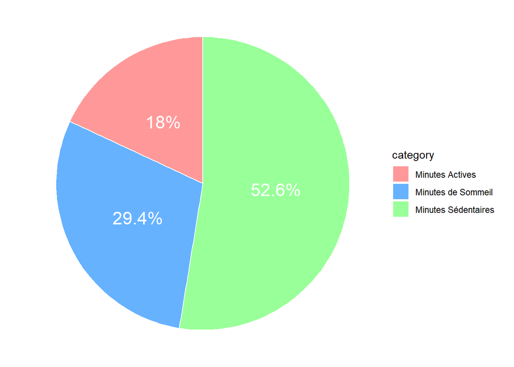

```r
total_active_minutes <- sum(result$ActiveMinutes)
total_sedentary_minutes <- sum(result$SedentaryMinutes)
total_sleep_minutes <- sum(result$TotalMinutesAsleep)

# Création d'un dataframe pour le camembert
pie_data <- data.frame(
  category = c('Minutes Actives', 'Minutes Sédentaires', 'Minutes de Sommeil'),
  value = c(total_active_minutes, total_sedentary_minutes, total_sleep_minutes)
)

# Définition des couleurs
colors <- c("#FF9999", "#66B2FF", "#99FF99")

# Création du camembert
ggplot(pie_data, aes(x = "", y = value, fill = category)) +
  geom_bar(stat = "identity", width = 1, color = "white") +
  coord_polar("y", start = 0) +
  theme_void() +
  geom_text(aes(label = paste0(round(value / sum(pie_data$value) * 100, 1), "%")),
            position = position_stack(vjust = 0.5), color = "white", size = 6) +
  scale_fill_manual(values = colors)
```

**Ces découvertes soulève plusieurs points :**

**Priorité à la sédentarité** : Si plus de la moitié du temps est sédentaire, cela pourrait indiquer que de **nombreux utilisateurs ont des emplois de bureau ou des routines quotidiennes qui ne nécessitent pas beaucoup de mouvement.** Cela pourrait également refléter la tendance croissante à consommer des contenus numériques (comme la télévision, les jeux vidéo ou la navigation sur Internet) qui encouragent un comportement sédentaire.

**Opportunités d’intervention** : Comprendre que la majorité des utilisateurs Fitbit sont sédentaires pendant une grande partie de la journée offre une opportunité d’intervention. Fitbit et d’autres technologies de santé pourraient utiliser ces informations pour **encourager plus d’activité physique à travers des rappels, des défis ou des récompenses.** **Cela nous apporte également des informations sur la clientèle potentielle Bellabeat.**

**Importance de l’activité modérée à intense** : Même si le pourcentage de minutes actives est relativement faible, il est essentiel de se rappeler que l’intensité de ces minutes peut avoir un impact significatif sur la santé. Par exemple, même une courte période d’activité intense peut offrir des bénéfices cardiovasculaires.

### 4.1.4 Nuage de points - Nombre de pas et callories brulées

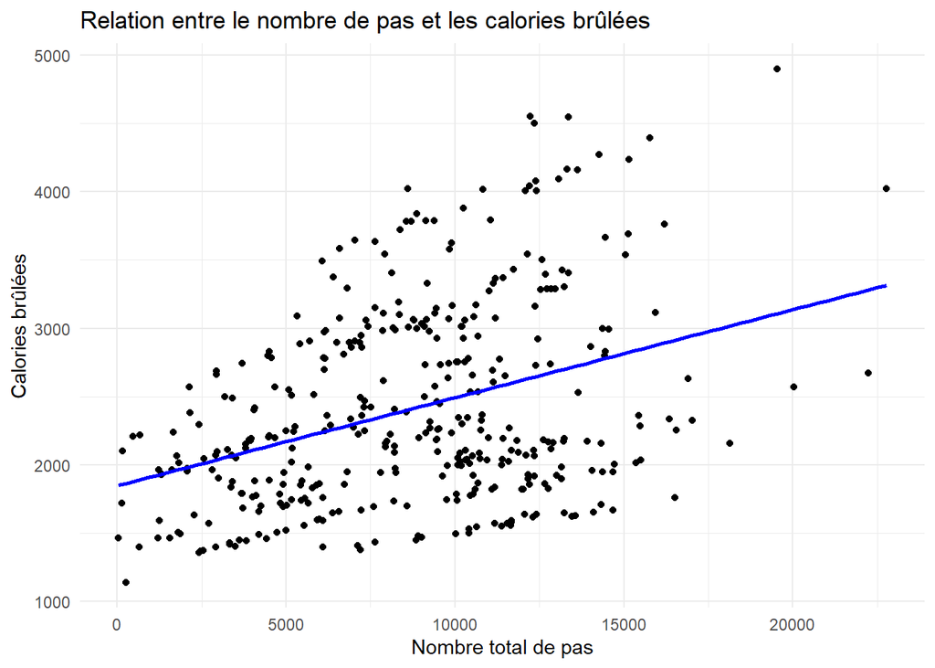

```r
ggplot(result, aes(x=TotalSteps, y=Calories)) +
  geom_point(alpha=0.5) +
  geom_smooth(method="lm", se=FALSE, color="blue") +  # Ajout d'une ligne de régression
  theme_minimal() +
  labs(title="Relation entre le nombre de pas et les calories brûlées",
       x="Nombre total de pas", y="Calories brûlées")
```

```r
#Calcul de la corrélation
correlation <- cor(result$TotalSteps, result$Calories, use="complete.obs")
correlation
```

```
## [1] 0.3612546
```

*Observations*

Il est important de noter que d’autres facteurs, tels que les minutes actives, l’intensité de l’activité, le métabolisme basal de l’individu, et même la composition corporelle, peuvent influencer le nombre total de calories brûlées. Se concentrer uniquement sur le nombre de pas pourrait donner une vue simplifiée de la situation.

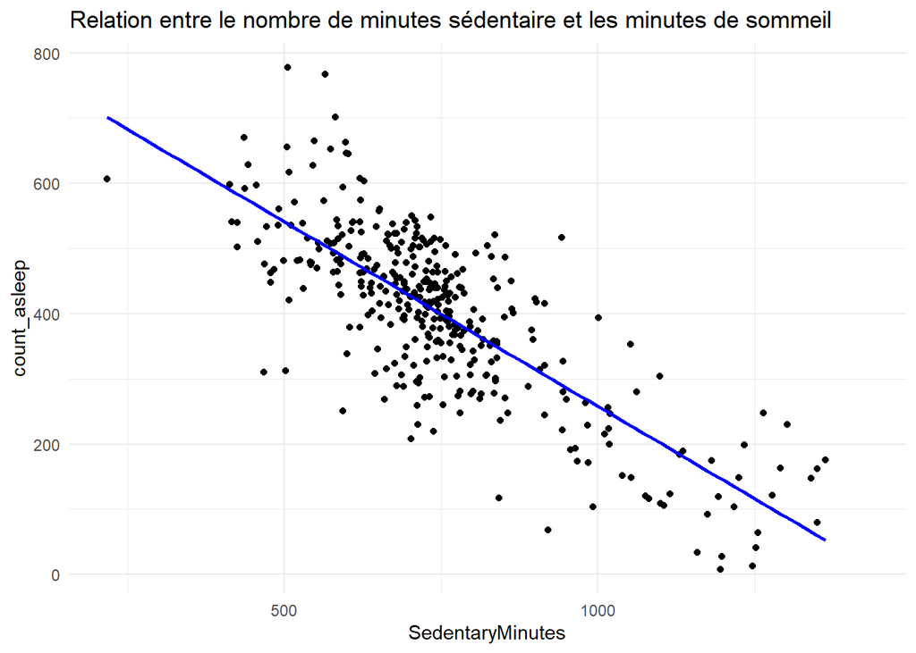

```r
ggplot(result, aes(x=SedentaryMinutes, y=count_asleep)) +
  geom_point(alpha=0.5) +
  geom_smooth(method="lm", se=FALSE, color="blue") +  # Ajout d'une ligne de régression
  theme_minimal() +
  labs(title="Relation entre le nombre de minutes sédentaire et les minutes de sommeil",
       x="SedentaryMinutes", y="count_asleep")
```

```r
#Calcul de la corrélation
correlation <- cor(result$SedentaryMinutes, result$count_asleep, use="complete.obs")
correlation
```

```
## [1] -0.7833958
```

*Observation* Il existe une corrélation négative significative de −0.783 entre les périodes de sommeil sans mouvement et les minutes sédentaires. Cela suggère que les individus qui sont moins sédentaires pendant la journée bénéficient d’un sommeil plus profond et moins agité la nuit. En d’autres termes, **une activité régulière pendant la journée pourrait être associée à une meilleure qualité de sommeil.**

*A noté que corrélation n’implique par lien de causalité, d’autres facteurs peuvent rentrer en jeu*

## 4.2 Conclusion de l’analyse

Suite à l’analyse des données, voici les principales conclusions :

**3)Corrélation entre l’activité et le sommeil :** Il existe une corrélation positive entre le nombre de pas et le nombre de calories brûlées, bien qu’elle ne soit pas très forte. Plus intéressant encore, une corrélation négative significative a été observée entre les périodes de sommeil sans mouvement et les minutes sédentaires, suggérant que moins de sédentarité pendant la journée pourrait conduire à un sommeil plus profond et moins agité la nuit.

**Sur la base de ces conclusions, il serait judicieux de proposer des interventions pour encourager une activité quotidienne accrue, réduire la sédentarité et sensibiliser à l’importance d’une bonne qualité de sommeil. Une telle démarche pourrait améliorer la santé générale et le bien-être des utilisateurs.**

# 5 Partager

### 5.0.1 Histogramme Heure de réveil

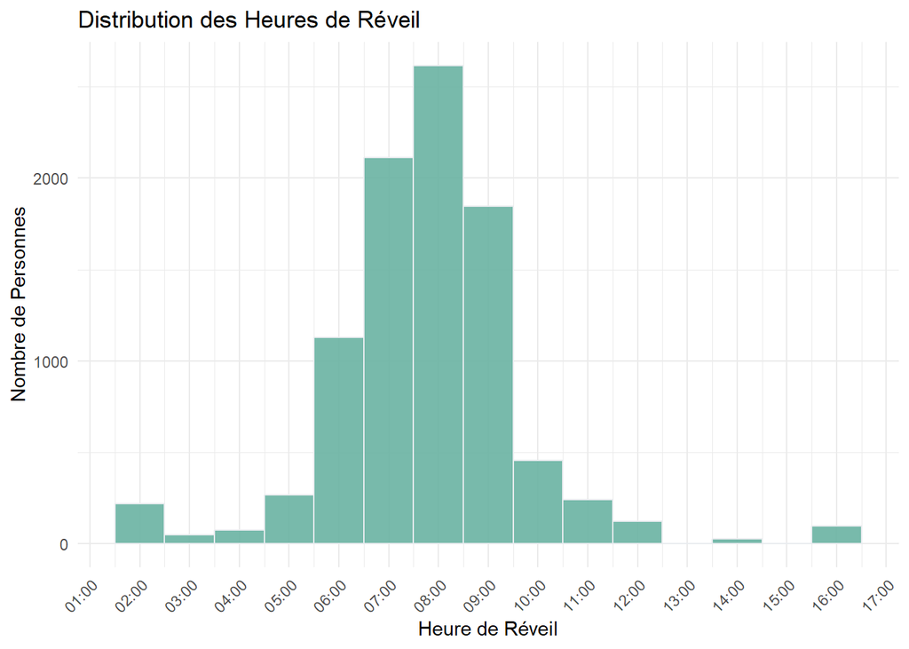

```r
# Conversion de la colonne wakeuptime en format Date/Heure
result$wakeuptime <- as.POSIXct(result$wakeuptime, format="%H:%M:%S")

# Création d'un histogramme pour visualiser la distribution des heures de réveil
ggplot(result, aes(x=wakeuptime)) +
    geom_histogram(binwidth=3600, fill="#69b3a2", color="#e9ecef", alpha=0.9) + # binwidth=3600 pour des intervalles d'une heure
    labs(title="Distribution des Heures de Réveil", x="Heure de Réveil", y="Nombre de Personnes") +
    theme_minimal() +
    scale_x_datetime(date_breaks = "1 hour", date_labels = "%H:%M") +
    theme(axis.text.x = element_text(angle = 45, hjust = 1))
```

Si nous supposons que la durée moyenne de sommeil est d’environ 7 à 8 heures, cela signifie que **la plupart des utilisateurs se couchent entre 22h00 et 01h00**.

**Pour maximiser la portée et l’efficacité de vos campagnes marketing, nous pourrions envisager de cibler les utilisateurs entre 20h00 et minuit, car cela serait juste avant leur heure de coucher présumée. Cela augmente la probabilité d’atteindre un plus grand nombre de clients potentiels lorsqu’ils sont le plus actifs et réceptifs.**

### 5.0.2 Pas par heure

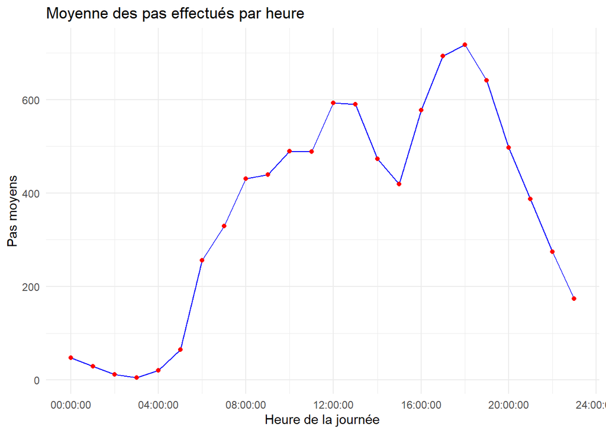

```r
# Grouping by the hour to calculate the mean steps for each hour
hourly_steps <- result %>%
  group_by(Hour_hms.x) %>%
  summarize(avg_steps = mean(StepTotal, na.rm = TRUE))

# Creating the plot
ggplot(hourly_steps, aes(x = Hour_hms.x, y = avg_steps)) +
  geom_line(color = "blue") +
  geom_point(color = "red") +
  labs(title = "Moyenne des pas effectués par heure",
       x = "Heure de la journée",
       y = "Pas moyens") +
  theme_minimal()
```

**Observation**

**En exploitant ces données, des stratégies peuvent être élaborées pour encourager les utilisateurs à bouger pendant les périodes creuses, optimisant ainsi leur niveau d’activité quotidien et luttant contre la sédentarité.**

# 6 Agir

Après avoir réalisé une analyse exhaustive, je suis impatient de présenter mes résultats et mes recommandations à l’équipe Bellabeat. Selon mon auditoire, j’ajusterai la teneur de mon discours. Si je m’adresse à l’équipe marketing, j’approfondirais les aspects techniques de l’analyse, notamment les étapes de préparation, de traitement et d’analyse des données. En revanche, si je présente à l’équipe de direction, je mettrai l’accent sur les conclusions dérivées des analyses et sur les étapes d’action à suivre. Suite aux feedbacks sur mon étude, j’élaborerai une stratégie pour apporter les modifications nécessaires et préparerai une présentation finale.

## 6.1 Recommandations

Voici mes recommandations basé sur l’analyse des données Fitbit et l’étude des fonctionnalités déjà présente du bracelet Bellabeat : *Ivy*

**1) Notifications Push :** - Envoyer une notification après un certain nombre de minutes inactives, cette nouvelle fonctionnalité permettra de lutter contre la sédentarité et d’améliorer la qualité de sommeil - Paramétrer un rappel basé sur l’objectif de sommeil pour aller se coucher en fonction du temps de sommeil souhaité et des data liéés à la journée actuelle

**2) Suivi de la qualité du sommeil :** - Ajouter une fonctionnalité : Réveil intelligent en fonction du temps de sommeil souhaité

**3) Campagne Marketing** - Ciblez nos campagnes marketing sur un profil spécifique : les utilisateurs Fitbit. Notre étude montre qu’ils sont principalement sédentaires, avec une forte probabilité d’avoir des emplois de bureau, et représentent donc une cible potentielle pour Bellabeat. -Ajuster nos campagnes marketing pour cibler ces individus entre 20h00 et minuit. C’est le moment où ils sont susceptibles d’être le plus actifs en ligne et réceptifs, juste avant leur heure de coucher habituelle. Cette stratégie pourrait augmenter significativement l’efficacité de nos efforts marketing.

**4)Feedback** - Donner aux utilisateurs la capacité de fournir des commentaires en direct sur leur activité quotidienne, tels que leurs mouvements, leur repos et d’autres indicateurs. Cette fonction améliorera la quantité de données recueillies et élargira notre domaine d’intervention.

*Bien que cette étude fournisse des insights précieux sur les utilisateurs de Fitbit, elle présente certaines limites importantes à considérer. Tout d’abord, Bellabeat se spécialise exclusivement dans la confection de produits féminins, tandis que les données de Fitbit englobent à la fois les hommes et les femmes. De plus, ces données sont anonymisées, rendant difficile la distinction précise entre les genres. Enfin, il est crucial de noter que mon analyse est basée sur un échantillon restreint de seulement 24 utilisateurs, ce qui pourrait ne pas représenter la diversité et la complexité de l’ensemble de la base d’utilisateurs de Fitbit.*

## 6.2 Conclusion

**À travers une démarche axée sur le consommateur, combinée à une analyse de données rigoureuse et à la prise en compte de retours en temps réel, Bellabeat peut non seulement optimiser l’expérience utilisateur de ses produits, mais aussi promouvoir un quotidien plus actif et sain pour sa clientèle.**

*Il s’agit de ma première analyse en tant qu’analyste de données. Toute remarque ou suggestion est la bienvenue. Merci par avance.*